# TSeries_Analysis_Midterm_exam

Juan Garbayo de Pablo

### Import libraries

```r
library(fpp3)
```

### 1. Import the .csv data and format it as a tsibble (**0 points**)

```r
unemp <- readr::read_csv("../datasets/spain_unemployment_format.csv")
# Convert column "date" to a yearmonth object
unemp <- unemp %>%
      mutate(date = yearmonth(date)) %>%
      as_tsibble()
```

```
## Using `date` as index variable.
```

### 2. Graphical analysis (**4 points**):

#### 2.1 Generate a timeplot of the data, adjusting its grid adequately to signal at least the end of every year (**1 point**)

```
## Plot variable not specified, automatically selected `.vars = unemp`
```

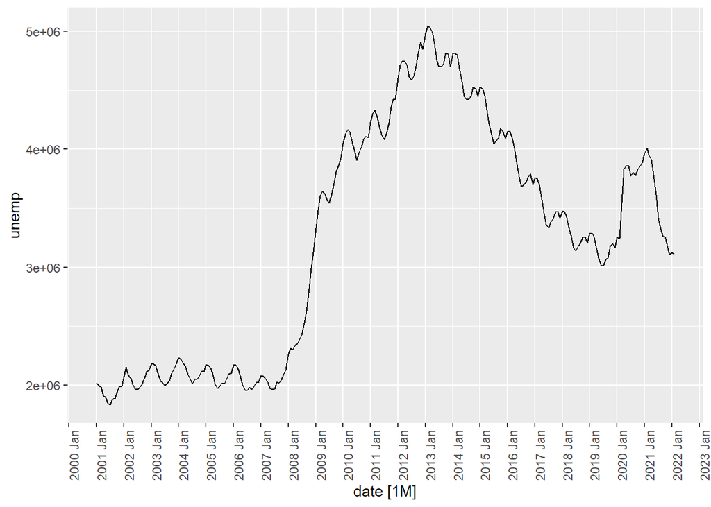

```r
unemp %>%
  autoplot() +

  scale_x_yearmonth(date_breaks = "1 year",
                    date_minor_breaks = "1 year") +

  # Flip x-labels by 90 degrees
  theme(axis.text.x = element_text(angle = 90))
```

#### 2.2 Generate a seasonal subseries plot (**0.5 points**)

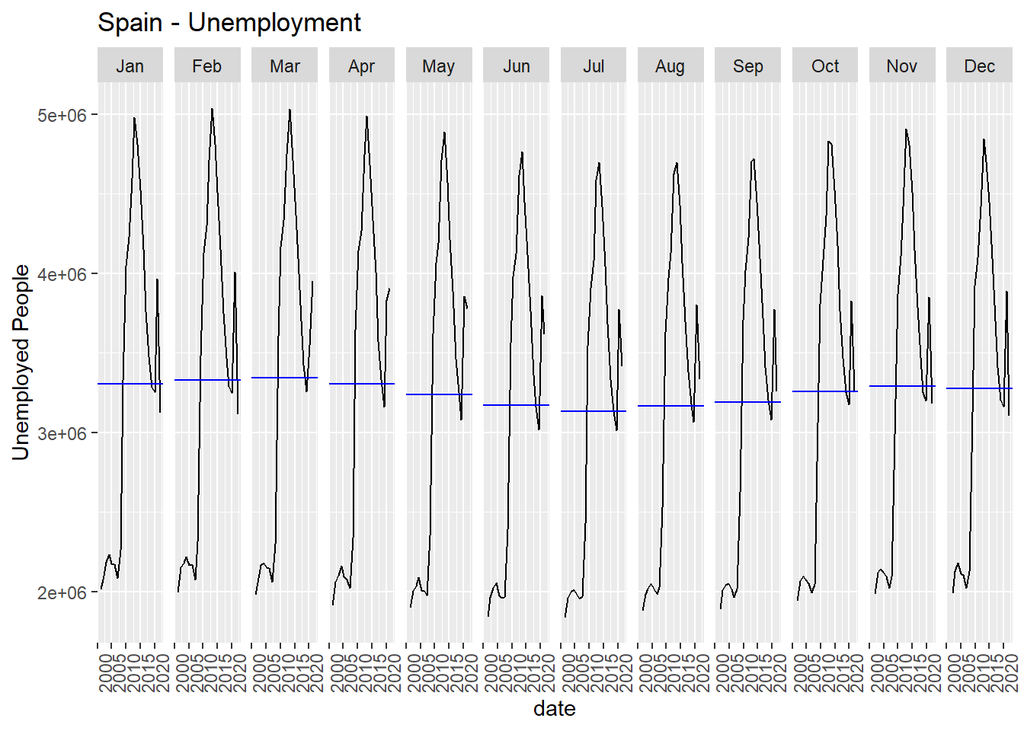

```r
unemp %>%
  gg_subseries(unemp) +
  labs(
    y = "Unemployed People",
    title = "Spain - Unemployment"
  )
```

#### 2.3 Answer the following questions based on the foregoing graphs (**1 point**)

1. Which period would you expect? (Justify briefly)

We are dealing with data that is collected once a month. The natural calendar period would be 1 year. The timeplot with an adequate grid suggests that this is a fair thing to expect.

2. Which is the average seasonal pattern exhibited by the unemployment in Spain? (Justify briefly)

The average seasonal component corresponds to the blue lines on the seasona sub-series plot. On average it appears that the unemployment increases from January to March, then decresaes until July and then increases again until the end of the year with a slight descent in December most likely due to a Christmas effect.

3. Would you say the series is multiplicative or additive? (Justify briefly)

The series seems to be additive. The seasonal variation does not seem to increase with the level of the series, indicating an additive pattern.

#### 2.4 Generate and interpret a correlogram of the series (**1.5 points**)

- IMPORTANT: extend the correlogram to cover at least 4 seasonal periods.

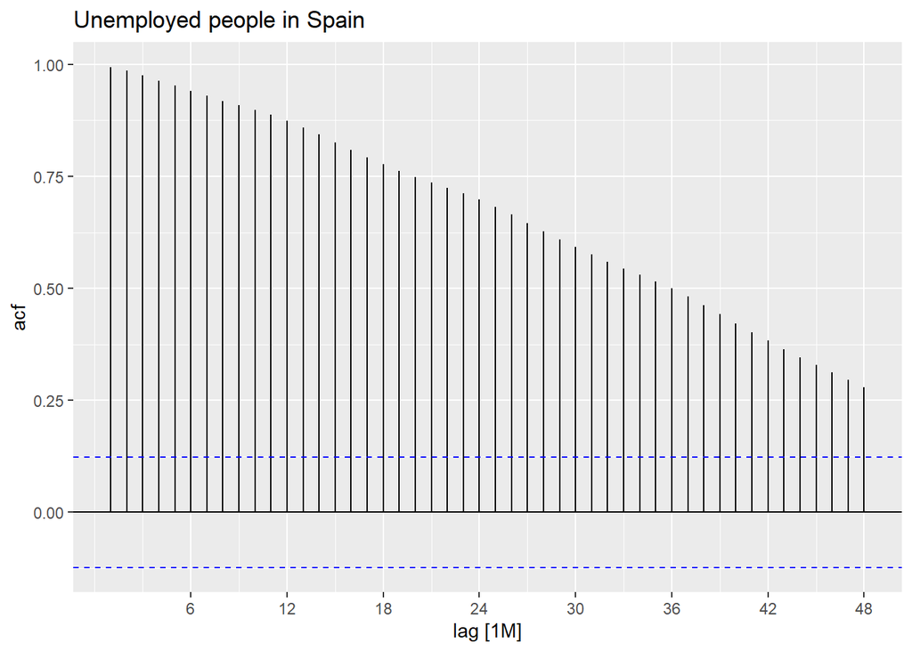

```r
unemp %>%
  ACF(unemp, lag_max = 48) %>%
  autoplot() +
  labs(title="Unemployed people in Spain")
```

For the interpretation, briefly answer these:

- Any particular pattern you can recognize?

A clear trend pattern (high and slowly decreasing correlation between adjacent lags) is visible.

- Can you spot the seasonality on the correlogram?. Why might this be?

On this correlogram the seasonality cannot be spotted. This is because the trend is much stronger than the seasonal component. In order to observe the effect of the seasonal component, we would need to at least detrend the series.

### 3. Decomposition (**3 points**)

#### 3.1 STL Decomposition with default arguments (**1 point**)

Use the default arguments for the STL decomposition. Depict the decomposition. Compare the seasonal and remainder components.

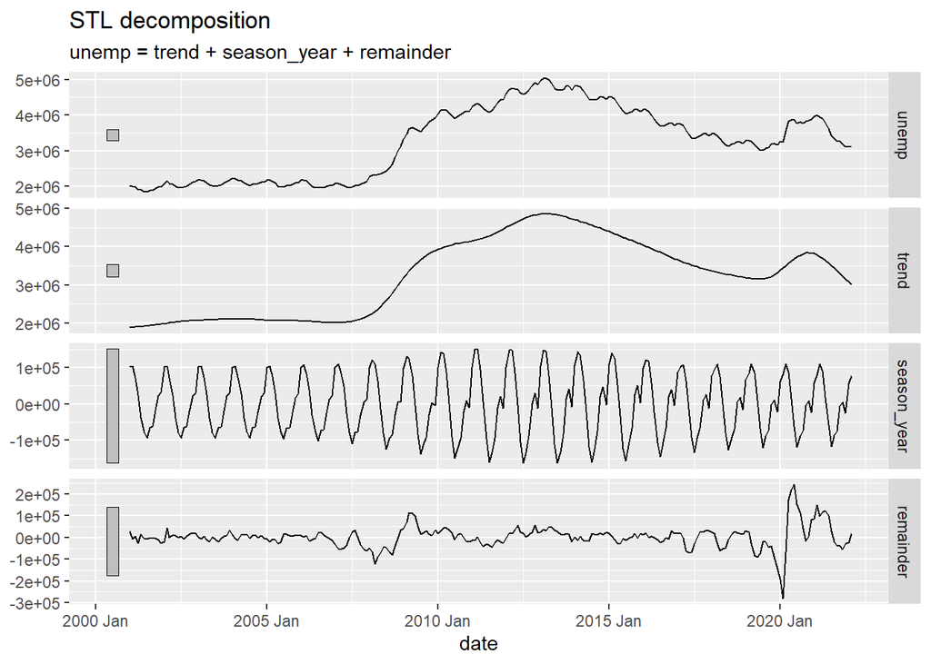

```r
unemp_cmp <- unemp %>%
              model(
                STL(unemp)
                ) %>%
              components()

autoplot(unemp_cmp)
```

- Are there any time periods that are not adequately captured by the decomposition? Pay attention to the remainder component and justify briefly your answer.

Observing the remainder component we observe two regions where its fluctuations increase: the 2008 crisis and the end of 2019/start of 2020. The increment is much clearer in the latter.

With the default arguments the trend and the seasonal component are not capable of adequately capturing the strong variations in unemployment associated with these two crisis periods. The averaging windows used are two wide.

- Does the relative magnitude of the resulting components make sense? (how big they are compared to one another). Justify briefly.

The decomposition shows that at least in the first quarter of 2020 the variation of the remainder component is much stronger than the variation of the seasonal component. Neither the seasonal component nor the trend are capable of capturing this variation and so it bleeds into the remainder component. The goal of the decomposition is having most of the variation (most of the infromation) captured by the seasonal and trend components. Therefore, at least locally, the decomposition is not adequate.

#### 3.2 Adjust the arguments used in the STL decomposition to improve the decomposition in those time regions. (**1 point**).

- NOTE: be sure to store the result of the decomposition in a separate variable prior to printing it. We will be working with the components.
- NOTE: the resulting decomposition may not be perfect regarding the homoskedasticity of the remainder, but there must be an improvement in the relative magnitude of the components.

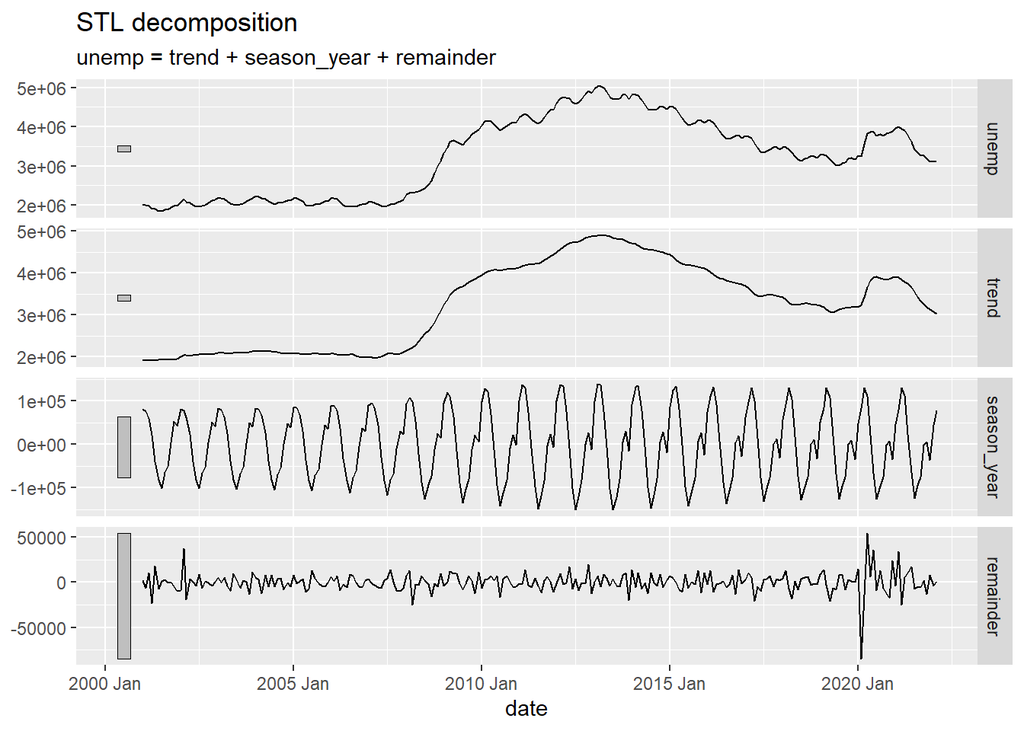

```r
unemp_cmp <- unemp %>%
              model(
                STL(unemp ~ trend(window = 5) + # Manually change this value from the default 13
                            season(window = 13))
                ) %>%
              components()

autoplot(unemp_cmp)
```

After adjusting the values, we still have a time region (first quarter of 2020) where the fluctuations of the remainder component increase. Refining the argumets is not able to solve this specific issue.

However, we observe that the magnitude of the remainder component is now at least smaller than that of the seasonal component, even in this region. Adjusting these arguments has led to substantial improvements in this sense.

#### 3.3 Generate the correlogram of the seasonal component. (**1 point**)

- Include at least 4 seasonal periods.
- Briefly interpret the correlogram.

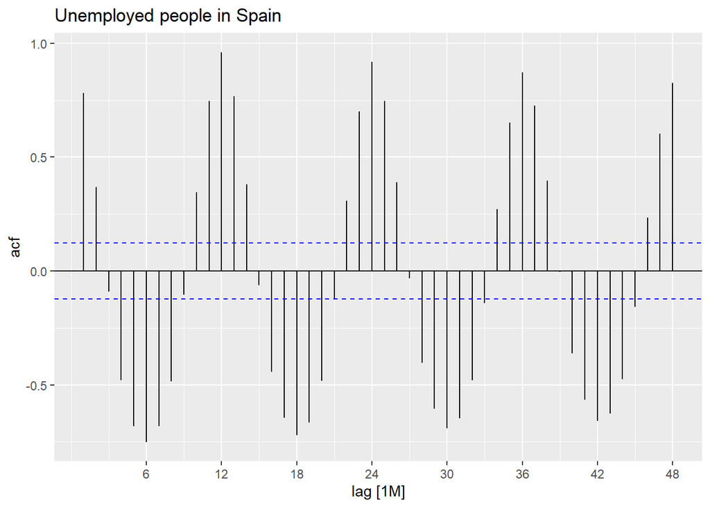

```r
unemp_cmp %>%
  ACF(season_year, lag_max = 48) %>%
  autoplot() +
  labs(title="Unemployed people in Spain")
```

The correlogram clearly shows that the strongest correlations occur at lags that are multiples of 12 (12, 24, 36…). This confirms the yearly seasonality of the series we were expecting to encounter.

### 4. Converting to quarterly data (**2 points**)

#### 4.1 Using `index_by()` compute a quarterly series based on the average quarterly unemployment **(1 point)**

- Store the result of the index_by() operation in a separate variable

```r
unemp_q_mean <- unemp %>%

  # Step 1: Indicate level of aggregation desired in the index. In this case
  # we will start with a weekly aggregation:
  index_by(quarter = yearquarter(date)) %>%

  # Step 2: aggregate variables with the desired output
  summarise(
    unemp = mean(unemp, na.rm = TRUE), # Computes the mean NO2 levels for each calendar week.
  )

unemp_q_mean
```

```
## # A tsibble: 85 x 2 [1Q]
##    quarter    unemp
##      <qtr>    <dbl>
##  1 2001 Q1 1997223.
##  2 2001 Q2 1883765.
##  3 2001 Q3 1867812
##  4 2001 Q4 1971828.
##  5 2002 Q1 2102677.
##  6 2002 Q2 2008652.
##  7 2002 Q3 1984206.
##  8 2002 Q4 2102892.
##  9 2003 Q1 2176290.
## 10 2003 Q2 2053481.
## # ... with 75 more rows
```

#### 4.2 Perform an STL decomposition of the result (**0.5 Points**)

- NOTE: you may use the default arguments or the arguments from question 4.3.

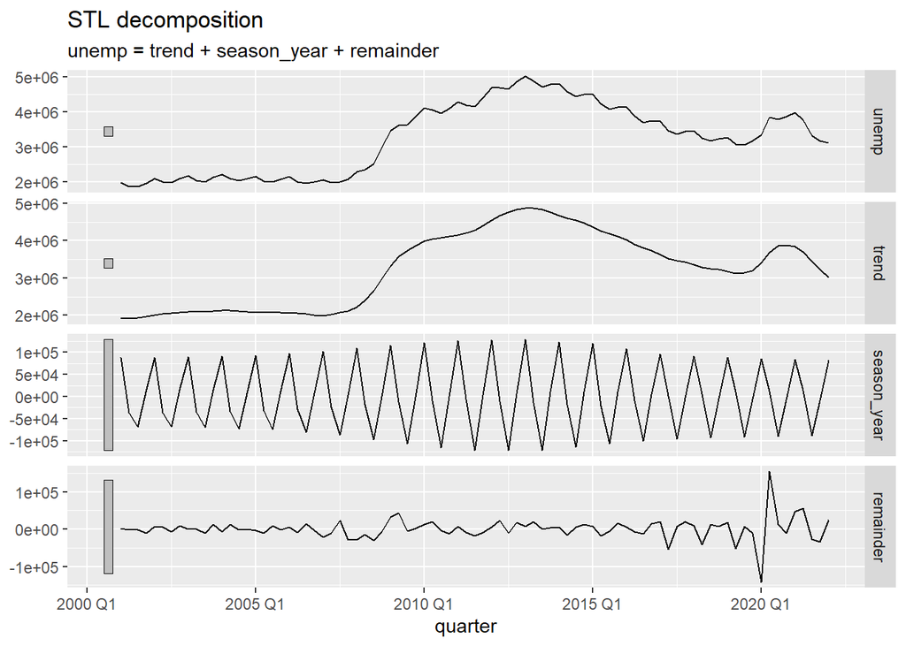

```r
unemp_q_mean_cmp <- unemp_q_mean %>%
                      model(
                        STL(unemp ~ trend(window = 5) + # Manually change this value from the default 13
                                    season(window = 13))
                        ) %>%
                      components()

autoplot(unemp_q_mean_cmp)
```

- Describe briefly how the seasonal component has changed compared to the decomposition of the original series.

The averaging process has removed all the monthly subtleties of the seasonal component. Instead of 12 data points per year it now has four and hence its much simpler aspect.

#### 4.3 Generate again the correlogram of the seasonal component (**0.5 Points**)

- Extend the results for at least 4 seasonal periods
- What can you say about the seasonal period?

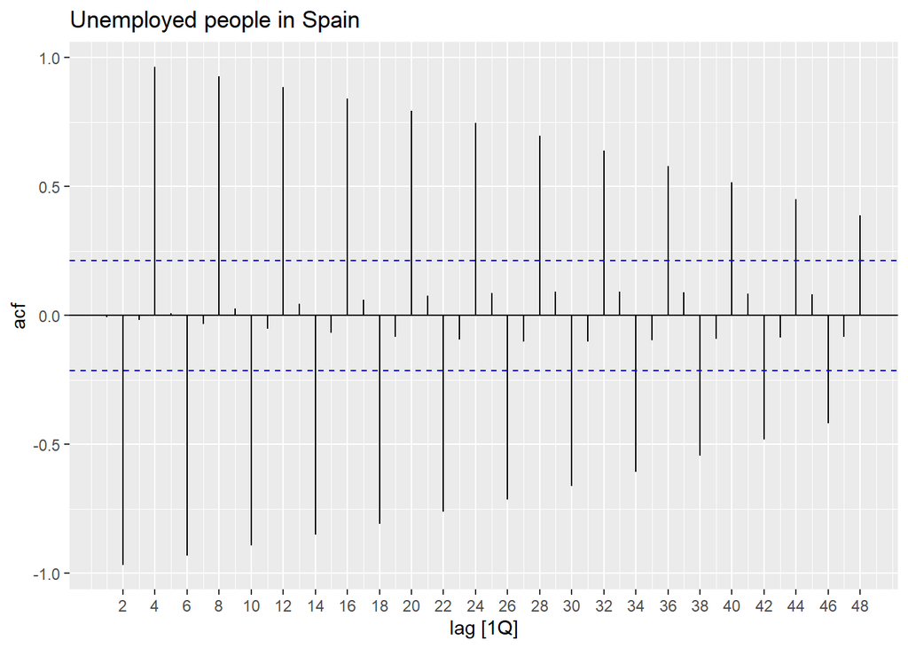

```r
unemp_q_mean_cmp %>%
  ACF(season_year, lag_max = 48) %>%
  autoplot() +
  labs(title="Unemployed people in Spain")
```

As expected the seasonal component now has periof 4 (4 quarters per year) and hence the strongest correlations are observes at multiples of 4 (4, 8, 12, 16…)

### 5. Time Series data wrangling (**1 point**)

So far, we have averaged the unemployment values over each quarter. Technically, to make the unemployment series quarterly starting from monthly data, we should pick up the value corresponding to the last month of every quarter.

Follow these steps to achieve this:

#### 5.1 Convert the original monthly series back to a tibble using `as_tibble()` and store it in a new variable (**0 points**)

```r
unemp_tb <- unemp %>% as_tibble()
```

#### 5.2 Generate a new column called `quarter` indicating the year and quarter of each data point using `mutate()` and `yearquarter()` (**0 points**)

```r
unemp_tb <- unemp_tb %>% mutate(quarter = yearquarter(date))
unemp_tb
```

```
## # A tibble: 254 x 3
##        date   unemp quarter
##       <mth>   <dbl>   <qtr>
##  1 2001 Jan 2017389 2001 Q1
##  2 2001 Feb 1993273 2001 Q1
##  3 2001 Mar 1981006 2001 Q1
##  4 2001 Apr 1910453 2001 Q2
##  5 2001 May 1898285 2001 Q2
##  6 2001 Jun 1842556 2001 Q2
##  7 2001 Jul 1835738 2001 Q3
##  8 2001 Aug 1878513 2001 Q3
##  9 2001 Sep 1889185 2001 Q3
## 10 2001 Oct 1940910 2001 Q4
## # ... with 244 more rows
```

#### 5.3. Using `group_by()` on this tibble combined with `max()`, generate a table (a tibble) that, for each quarter, details the last month of the quarter. Store it in a new variable. (**0.5 points**)

- **NOTE**: the key here was to realize that dates (and times) are a set that admits ordering (where comparisons such as *smaller than* or *greater than* are possible). The max() function is able to make use of this to determine the last month within each of the subgroups created when grouping by quarter.

In fact, if you go over session 2_3, you will see that we explained there that dates and times are measured as elapsed time from a given origin (usually but not necessarily 1970-01-01).

```r
q_last_month <-unemp_tb %>%
  group_by(quarter) %>%
  summarise(
    l_month = max(date)
  ) %>%
  ungroup()

q_last_month
```

```
## # A tibble: 85 x 2
##    quarter  l_month
##      <qtr>    <mth>
##  1 2001 Q1 2001 Mar
##  2 2001 Q2 2001 Jun
##  3 2001 Q3 2001 Sep
##  4 2001 Q4 2001 Dec
##  5 2002 Q1 2002 Mar
##  6 2002 Q2 2002 Jun
##  7 2002 Q3 2002 Sep
##  8 2002 Q4 2002 Dec
##  9 2003 Q1 2003 Mar
## 10 2003 Q2 2003 Jun
## # ... with 75 more rows
```

#### 5.4. Using a `left_join()` between this new tibble and the original monthly tsibble, obtain a series that keeps only one data point per quarter (the point corresponding to the latest month of each quarter). (**0.5 points**)

- **NOTE**: the key here is to swap the order of the tables to be joined so that **q_last_month** is the **left table** (the table that determines which rows are be kept in the join operation).

```r
unemp_q <- left_join(q_last_month, unemp, by=c("l_month" = "date")) %>%
  as_tsibble(index = quarter)
unemp_q
```

```
## # A tsibble: 85 x 3 [1Q]
##    quarter  l_month   unemp
##      <qtr>    <mth>   <dbl>
##  1 2001 Q1 2001 Mar 1981006
##  2 2001 Q2 2001 Jun 1842556
##  3 2001 Q3 2001 Sep 1889185
##  4 2001 Q4 2001 Dec 1988716
##  5 2002 Q1 2002 Mar 2083103
##  6 2002 Q2 2002 Jun 1962963
##  7 2002 Q3 2002 Sep 2006785
##  8 2002 Q4 2002 Dec 2127018
##  9 2003 Q1 2003 Mar 2163499
## 10 2003 Q2 2003 Jun 2020367
## # ... with 75 more rows
```